# MRO: Laboratorium 3 - KNN

# Piotr Rząsa

## 1) Odtwarzanie obrazów przy pomocy KNN

**Komentarz do wyników uzyskanych poniżej:**  
Poniżej zaprezentowałem 3 zbiory wynikowe, każdy dla innego romiaru zbioru treningowego.  
Dzięki zastosowaniu obrazka z napisem oraz tłem z dużą ilością szczegółów byłem w stanie dość dobrze porównać wyniki i dojść do ciekawych wniosków.  
Każdy zbiór zawiera przykładowy wynik dla jednej z instancji testowych dla k=1,3,10 orz obrazek uśredniony dla podanych 'k'. Dalej są obok siebie oryginalne zdjęcie i uśrednienie dla wszystkich 5 prób (w teorii najlepszy z obrazków).  
Obserwując wyniki można zauważyć, że samodzielny wynik dla pojedynczego K dawał zazwyczaj albo nieostry, albo bardzo "zaszumiony" obraz - wiele wyróżniających się pikseli nie pasujących do otoczenia.  
Natomiast uśrednienie dla 3 różnych k pozwalało na uzyskanie dużo lepszego wyniku - o wiele bardziej zbliżonego do oryginału.  
Zebranie średniego obrazka z 5 prób dawało natomiast obrazek zupełnie pozbawiony szumów i delikatnie rozmyty, pozbawiony ostrych krawędzi. Być może nie zawsze był on czytelniejszy od oryginału, ale w pewnym sensie uważam że "przyjemniejszy" dla oka i zdecydowanie najlepszy.  
Pozwala to dojść do wniosku, że dopiero wzięcie pod uwagę kilku różnych wyników z różnymi parametrami pozwala na uzyskanie satysfakcjonującego wyniku - usuwa to wszelkie punktowe niedoskonałości, poprzez umniejszanie ich roli w czasie uśredniania.

```
Rozwiązanie dla zbioru treningowego = 0.1
```

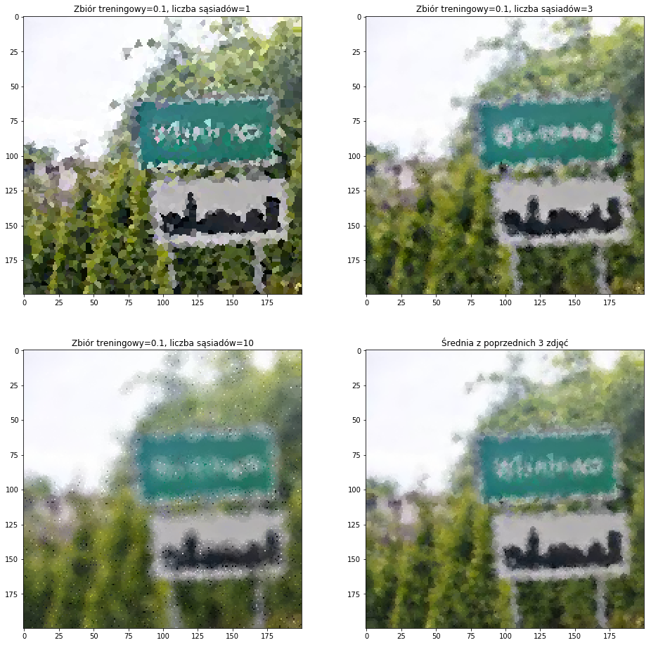

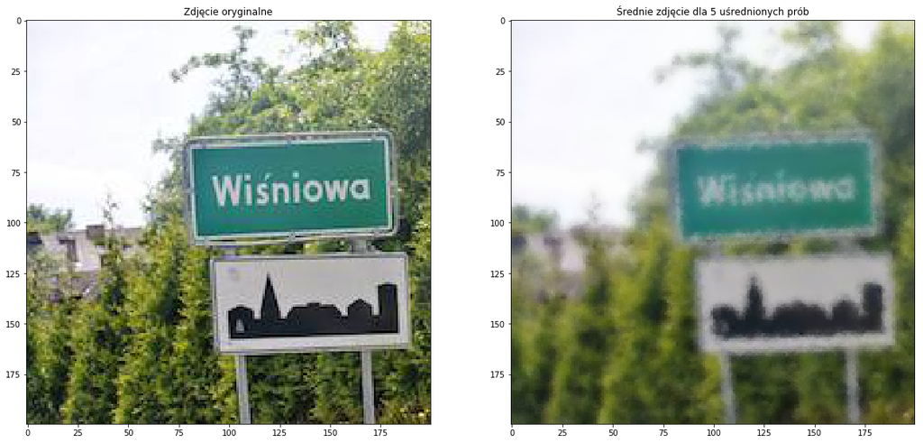

```python
get_complex_solution(0.1)
```

```
Rozwiązanie dla zbioru treningowego = 0.5
```

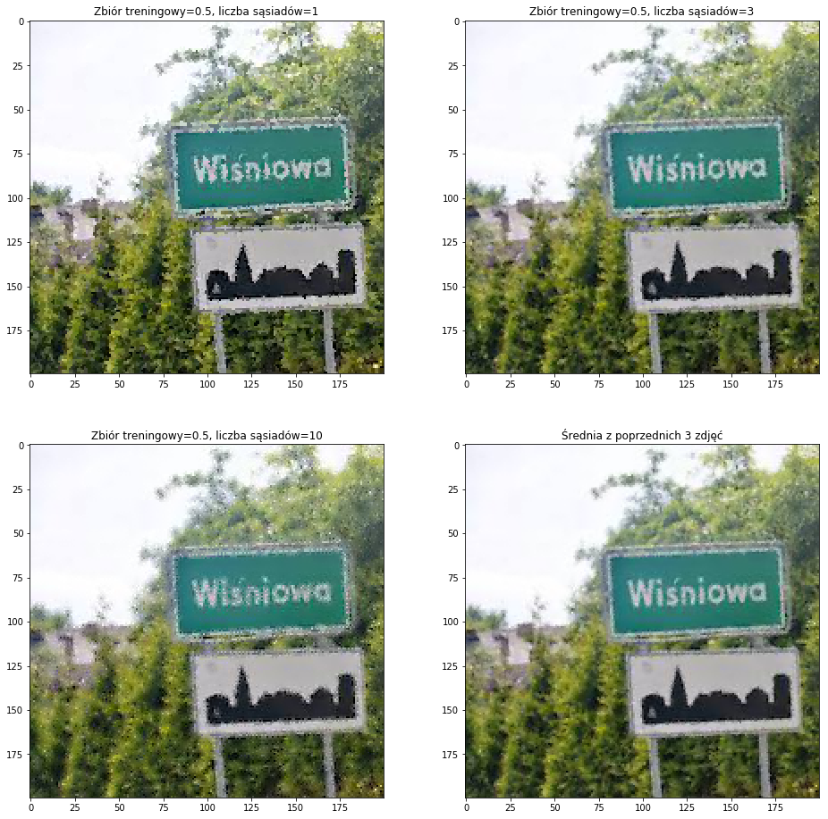

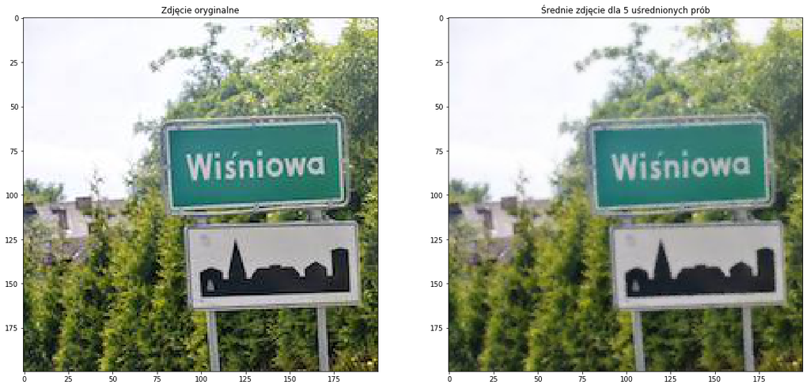

```python
get_complex_solution(0.5)
```

```
Rozwiązanie dla zbioru treningowego = 0.75
```

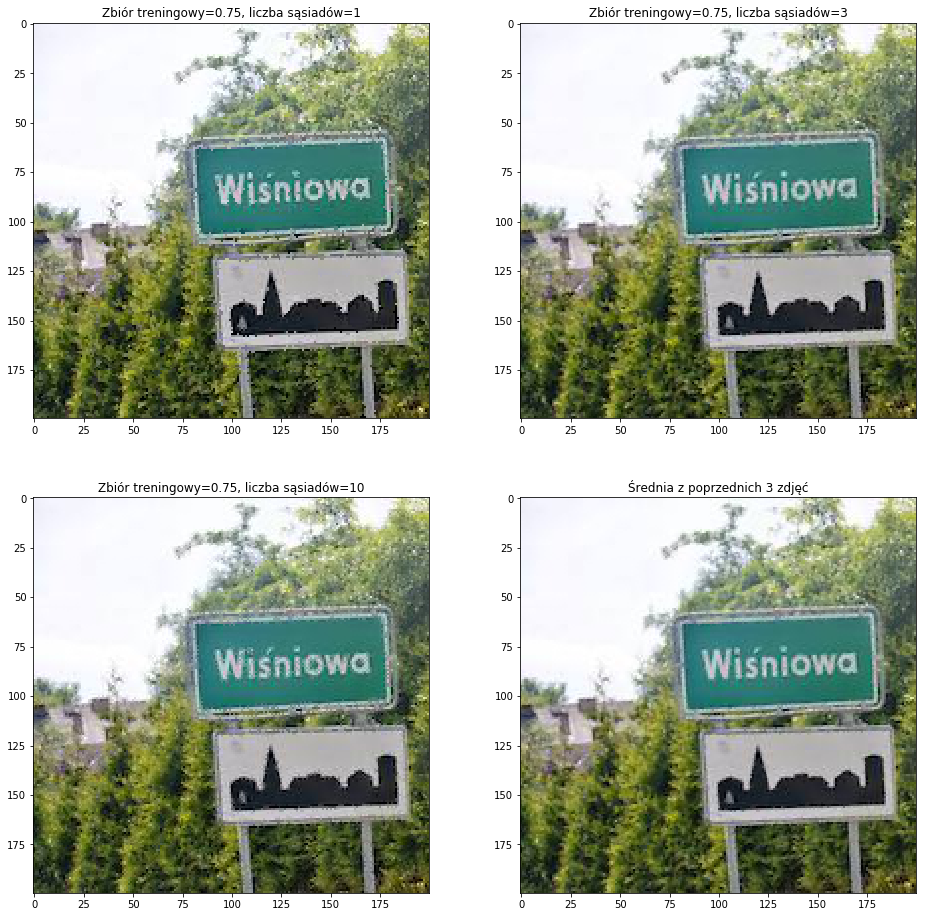

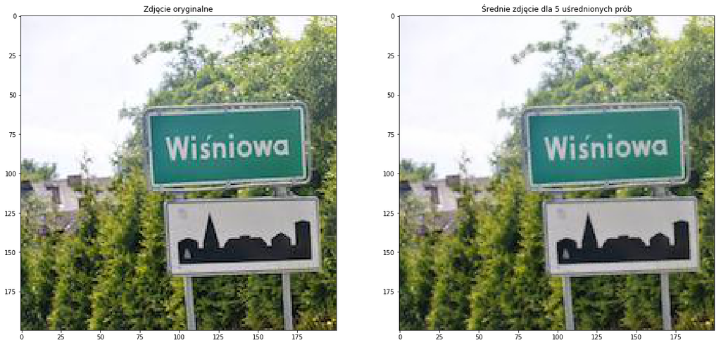

```python
get_complex_solution(0.75)
```